# Heart diseases feature selection and exploratory data analysis

Wangjun Shen

# Introduction

The objective of this assignment is to prepare a data set that can be used to predict heart disease, a common and serious health issue that affects a significant portion of the population. The data set we will be working on is a subset of a larger real-world data set collected by multiple healthcare institutions. It contains various attributes related to patients’ health, such as age, gender, blood pressure, and other clinical measurements. These attributes can be leveraged to predict the presence of heart disease.

Data mining plays a critical role in addressing challenges related to predicting disease spread and similar healthcare problems. By analyzing large and complex data sets, we can identify patterns and relationships that may not be immediately apparent. This, in turn, allows us to develop more accurate predictive models. In the context of heart disease, data mining techniques can help us extract insights and patterns from patient data. These insights can aid in identifying risk factors, predicting disease outcomes, and developing effective treatment strategies.

For example, by using data mining techniques on the given data set, we can identify the most important predictors of heart disease. This knowledge can then be used to develop a classification model that accurately predicts the presence of the disease in patients. Moreover, data mining can also help us identify subpopulations that are more susceptible to the disease. We can then develop tailored prevention and treatment strategies for these subpopulations.

Overall, this assignment provides an opportunity to apply data mining techniques to a real-world data set. It also allows us to gain hands-on experience with feature engineering, data exploration, and predictive modeling. The insights gained from this exploration can inform our work in subsequent assignments. This, in turn, can help us develop more accurate and effective predictive models for heart disease and other similar health challenges.

# Data exploration

## Features Selection

The details of the original data set are as follows.

| Variable | Description | Type |
| --- | --- | --- |
| id | A unique ID that identifies a participant in the study | Numerical |
| age | Age in years | Numerical |
| sex | Male and Female were recorded | Categorical |
| cp | Chest Pain type: typical angina; atypical angina; non-anginal pain; and asymptomatic | Categorical |
| trestbps | Resting blood pressure (in mm Hg on admission to the hospital) | Numerical |
| chol | Serum Cholestoral in mg/dl | Numerical |
| fbs | Fasting blood sugar > 120 mg/dl (True or False) | Boolean |
| restecg | Resting electrocardiographic results: normal; having ST-T wave abnormality (T wave inversions and/or ST elevation or depression of > 0.05 mV) or showing probable or definite left ventricular hypertrop… | Categorical |
| thalach | Maximum heart rate achieved | Numerical |
| exang | Exercise induced angina (True/False) | Boolean |
| oldpeak | ST depression induced by exercise relative to rest | Numerical |
| slope | The slope of the peak exercise ST segment: upsloping; flat; downsloping | Categorical |
| major_vessels | Number of major vessels (0-3) colored by flourosopy | Numerical |
| restwm | Rest wall motion abnormality: none; mild or moderate; moderate or severe; akinesis or dyskmem | Categorical |
| target | Heart disease diagnosed (disease/no disease) | Categorical |

Import the data set and view.

```r
# load data set first
heart.full <- read.csv("heart.csv")

# then check the data set
str(heart.full)
```

```
'data.frame':   1025 obs. of  15 variables:
 $ id           : int  1 2 3 4 5 6 7 8 9 10 ...
 $ age          : int  52 53 70 61 62 58 58 55 46 54 ...
 $ sex          : chr  "male" "male" "male" "male" ...
 $ cp           : chr  "typical angina" "typical angina" "typical angina" "typical angina" ...
 $ trestbps     : int  125 140 145 148 138 100 114 160 120 122 ...
 $ chol         : int  212 203 174 203 294 248 318 289 249 286 ...
 $ fbs          : logi  FALSE TRUE FALSE FALSE TRUE FALSE ...
 $ restecg      : chr  "ST-T wave abnormality" "normal" "ST-T wave abnormality" "ST-T wave abnormality" ...
 $ thalach      : int  168 155 125 161 106 122 140 145 144 116 ...
 $ exang        : logi  FALSE TRUE TRUE FALSE FALSE FALSE ...
 $ oldpeak      : num  1 3.1 2.6 0 1.9 1 4.4 0.8 0.8 3.2 ...
 $ slope        : chr  "downsloping" "upsloping" "upsloping" "downsloping" ...
 $ major_vessels: int  2 0 0 1 3 0 3 1 0 2 ...
 $ restwm       : chr  "akinesis or dyskmem" "akinesis or dyskmem" "akinesis or dyskmem" "akinesis or dyskmem" ...
 $ target       : chr  "no disease" "no disease" "no disease" "no disease" ...
```

From the output results, it can be found that the data set contains 15 variables and 1025 observation. The details of each variable are consistent with the description.

Then check the distribution of missing values in the data set.

```r
sum(is.na(heart.full))
```

```
[1] 0
```

There are not missing values in this data.

In the following section, we will discuss the importance of features, specifically the correlation between variables. To measure this correlation, we will use random forest to calculate Gini Importance or Mean Decrease in Impurity (MDI). This method determines the importance of each feature by summing the number of splits (across all trees) that include the feature, proportionally to the number of samples it splits.

```r
# convert age, trestbps, chol, thalach, and oldpeak to numeric
heart.full$age <- as.numeric(heart.full$age)
heart.full$trestbps <- as.numeric(heart.full$trestbps)
heart.full$chol <- as.numeric(heart.full$chol)
heart.full$thalach <- as.numeric(heart.full$thalach)
heart.full$oldpeak <- as.numeric(heart.full$oldpeak)


# convert sex, cp, restecg, slope, restwm, and target to factor
heart.full$sex <- as.factor(heart.full$sex)
heart.full$cp <- as.factor(heart.full$cp)
heart.full$restecg <- as.factor(heart.full$restecg)
heart.full$slope <- as.factor(heart.full$slope)
heart.full$restwm <- as.factor(heart.full$restwm)
heart.full$target <- as.factor(heart.full$target)
```

For ease of observation, we visualize the correlation.

[figure not shown]

```r
library(corrplot)

corrplot(cor.matrix, method = "color")
```

The resulting plot will show the correlations between variables using different colors, where red indicates strong negative correlation, blue indicates strong positive correlation, and white indicates no correlation. The strength of the correlation is determined by the absolute value of the correlation coefficient, with values closer to 1 indicating stronger correlation.

Then use random forest to detect the importance of each feature. In order to understand whether these features differ between genders, the data will firstly be created based on the sub-dataset.

```r
# data set for each gender
heart.male <- subset(heart.full, sex == "male")
heart.female <- subset(heart.full, sex == "female")
```

Then use those two sub datasets to build the random forest:

```r
# Random forest for male subset
library(randomForest)
set.seed(123)
rf_model_male <- randomForest(target ~ ., data = heart.male, importance = TRUE, ntree = 500)
importance(rf_model_male)
```

```
                disease no disease MeanDecreaseAccuracy MeanDecreaseGini
id             1.606825   3.213858             3.376221        11.154653
age           33.928469  40.857084            42.838250        34.448119
sex            0.000000   0.000000             0.000000         0.000000
cp            38.745483  36.059468            41.121602        47.161819
trestbps      33.903759  37.024285            41.751265        25.962476
chol          34.122660  35.756098            39.121768        29.972875
fbs           16.795603  16.203869            19.636756         3.761825
restecg       19.083360  19.416802            21.509917         5.531215
thalach       37.581333  37.899592            43.252118        51.572260
exang         17.532815  19.401905            20.468760        11.933409
oldpeak       32.589020  38.902000            40.817055        37.108368
slope         24.318522  24.566740            27.686364        17.111266
major_vessels 37.680805  40.115231            43.835239        42.184090
restwm        31.201322  32.398437            34.984151        25.367047
```

- cp (chest pain type)
- thalach (maximum heart rate achieved)
- major_vessels (number of major vessels colored by fluoroscopy)
- oldpeak (ST depression induced by exercise relative to rest)
- trestbps (resting blood pressure)
- age

Overall, these six features can be considered the most important for predicting the presence of heart disease for male in this dataset.

Visualization.

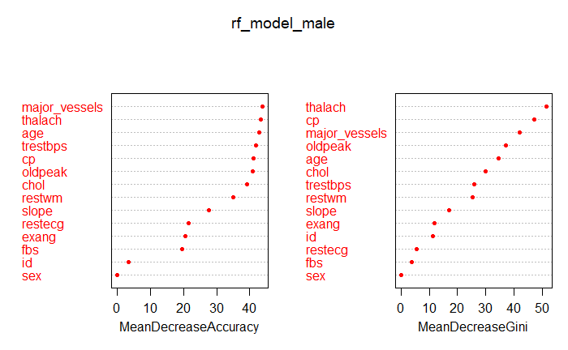

```r
varImpPlot(rf_model_male, col = "red", pch = 20)
```

```r
# Random forest for female subset
set.seed(123)
rf_model_female <- randomForest(target ~ ., data = heart.female, importance = TRUE, ntree = 500)
importance(rf_model_female)
```

```
                disease no disease MeanDecreaseAccuracy MeanDecreaseGini
id             1.932703  -3.148355           -0.5202009         2.590325
age           23.376089  24.724758           28.2364781        12.018921
sex            0.000000   0.000000            0.0000000         0.000000
cp            19.702221  20.271296           22.9715941        12.537614
trestbps      18.409296  18.651176           22.1370717         8.429236
chol          19.941082  22.898914           25.6314494         8.321454
fbs            7.611649   9.737944           10.2944996         1.418907
restecg       14.299858  15.552097           17.3754050         2.982791
thalach       19.430050  20.969639           24.2566433         8.272732
exang         18.303884  21.574578           22.6248431         9.167964
oldpeak       20.677704  21.784792           24.3639560        16.486048
slope         17.218824  19.973871           21.5111294         8.150365
major_vessels 19.573486  20.510840           22.7582749        10.407631
restwm        22.156482  24.907233           26.5256308        22.290165
```

Visualization.

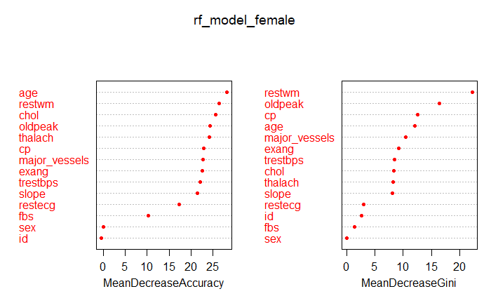

```r
varImpPlot(rf_model_female, col = "red", pch = 20)
```

Therefore, comprehensive consideration, the features that will be retained are: age, cp, thalach, oldpeak, major_vessels, restwm, exang and sex.

Now create a new data set with those selected features.

```r
# Create new dataset with selected features and target variable
heart_features_selected <- heart.full[, c("id", "age", "sex", "cp", "thalach", "exang", "oldpeak", "major_vessels", "restwm", "target")]

# Save new dataset as CSV file
write.csv(heart_features_selected, "heart_features_selected.csv", row.names = FALSE)
```

## Descriptive Statistics

Import the new data set and check the details of that new data set:

```r
heart.selected <- read.csv("heart_features_selected.csv")

str(heart.selected)
```

```
'data.frame':   1025 obs. of  10 variables:
 $ id           : int  1 2 3 4 5 6 7 8 9 10 ...
 $ age          : int  52 53 70 61 62 58 58 55 46 54 ...
 $ sex          : chr  "male" "male" "male" "male" ...
 $ cp           : chr  "typical angina" "typical angina" "typical angina" "typical angina" ...
 $ thalach      : int  168 155 125 161 106 122 140 145 144 116 ...
 $ exang        : logi  FALSE TRUE TRUE FALSE FALSE FALSE ...
 $ oldpeak      : num  1 3.1 2.6 0 1.9 1 4.4 0.8 0.8 3.2 ...
 $ major_vessels: int  2 0 0 1 3 0 3 1 0 2 ...
 $ restwm       : chr  "akinesis or dyskmem" "akinesis or dyskmem" "akinesis or dyskmem" "akinesis or dyskmem" ...
 $ target       : chr  "no disease" "no disease" "no disease" "no disease" ...
```

Summarize the selected data set:

```r
library(tidyverse)


heart.selected$id <- as.numeric(heart.selected$id)
heart.selected$age <- as.numeric(heart.selected$age)
heart.selected$sex <- as.factor(heart.selected$sex)
heart.selected$cp <- as.factor(heart.selected$cp)
heart.selected$thalach <- as.numeric(heart.selected$thalach)
heart.selected$oldpeak <- as.numeric(heart.selected$oldpeak)
heart.selected$major_vessels <- as.numeric(heart.selected$major_vessels)
heart.selected$target <- as.factor(heart.selected$target)


summary(heart.selected[, -1])
```

[output not shown]

```r
library(psych)

describe(heart.selected[, -1])
```

|  | vars | n | mean | sd | median | trimmed | mad | min | max | range | skew | kurtosis | se |
| --- | --- | --- | --- | --- | --- | --- | --- | --- | --- | --- | --- | --- | --- |
| age | 1 | 1025 | 54.43 | 9.07 | 56.0 | 54.66 | 8.90 | 29 | 77.0 | 48.0 | -0.25 | -0.53 | 0.28 |
| sex* | 2 | 1025 | 1.70 | 0.46 | 2.0 | 1.74 | 0.00 | 1 | 2.0 | 1.0 | -0.85 | -1.28 | 0.01 |
| cp* | 3 | 1025 | 3.17 | 0.96 | 3.0 | 3.31 | 1.48 | 1 | 4.0 | 3.0 | -0.86 | -0.39 | 0.03 |
| thalach | 4 | 1025 | 149.11 | 23.01 | 152.0 | 150.40 | 23.72 | 71 | 202.0 | 131.0 | -0.51 | -0.10 | 0.72 |
| exang | 5 | 1025 | NaN | NA | NA | NaN | NA | Inf | -Inf | -Inf | NA | NA | NA |
| oldpeak | 6 | 1025 | 1.07 | 1.18 | 0.8 | 0.89 | 1.19 | 0 | 6.2 | 6.2 | 1.21 | 1.29 | 0.04 |
| major_vessels | 7 | 1025 | 0.75 | 1.03 | 0.0 | 0.57 | 0.00 | 0 | 4.0 | 4.0 | 1.26 | 0.68 | 0.03 |
| restwm* | 8 | 1025 | 2.14 | 0.97 | 3.0 | 2.17 | 0.00 | 1 | 4.0 | 3.0 | -0.25 | -1.81 | 0.03 |
| target* | 9 | 1025 | 1.49 | 0.50 | 1.0 | 1.48 | 0.00 | 1 | 2.0 | 1.0 | 0.05 | -2.00 | 0.02 |

**首先对年龄进行探索**

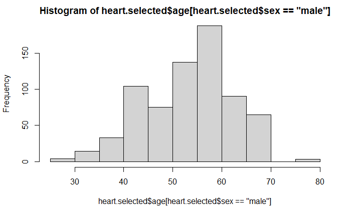

```r
hist(heart.selected$age[heart.selected$sex == "male"])
```

对于male的年龄而言，基本上是对称的，或者可以认为略微的有些左偏态分布。

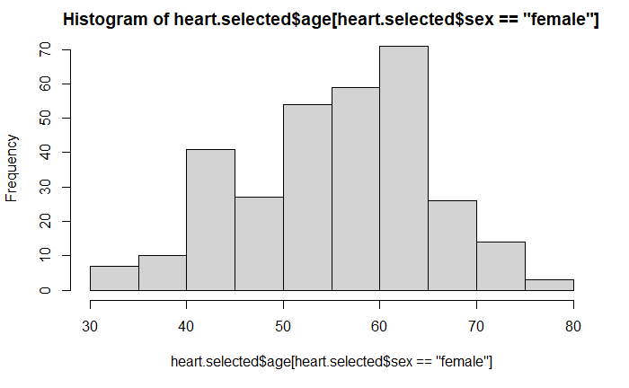

```r
hist(heart.selected$age[heart.selected$sex == "female"])
```

female的age相较于male的年龄分布而言，更加的左偏态分布，可以发现female在70以上的数量比male要多。

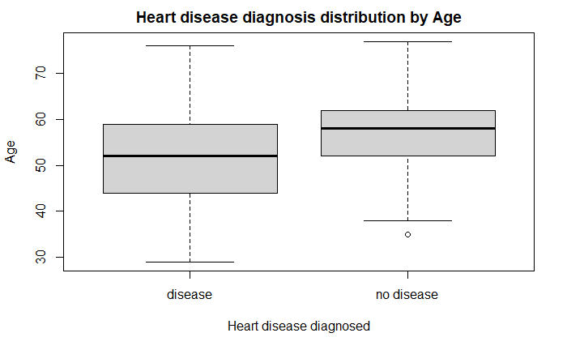

```r
boxplot(heart.selected$age ~ heart.selected$target,
        main="Heart disease diagnosis distribution by Age",
         ylab="Age",xlab="Heart disease diagnosed")
```

No disease的年龄median比disease的要高，而range则相对更小，no disease包含了一个outlier，但是不是extreme outlier，所以这个数据可以被保留而不是删除。

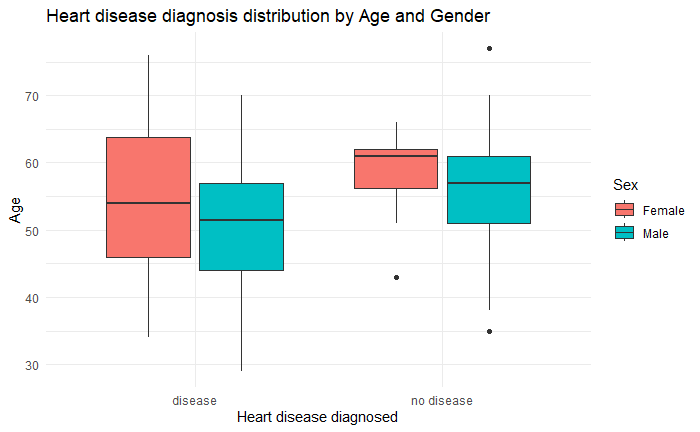

```r
ggplot(heart.selected, aes(x = target, y = age, fill = sex)) +
  geom_boxplot() +
  labs(title = "Heart disease diagnosis distribution by Age and Gender",
       x = "Heart disease diagnosed",
       y = "Age") +
  scale_fill_discrete(name = "Sex",
                      labels = c("Female", "Male")) +
  theme_minimal()
```

```r
NA
NA
```

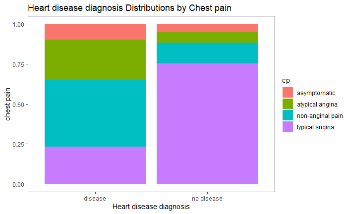

```r
ggplot(data = heart.selected, aes(x = target, fill = cp)) +
  geom_bar(position = "fill") +
  labs(title = "Heart disease diagnosis Distributions by Chest pain",
       x = "Heart disease diagnosis",
       y = "chest pain") +
  theme_test()
```

```r
NA
NA
```

cp一共有四种情况，在disease和no disease中的占比存在着区别。对于disease而言，有着non-anginal pain有着最高的占比，接着是atypical angina，而asymptomatic的占比则最小。

对于no disease而言，typical angina有着最高的占比，而且显著的高于了在disease上的占比，其他的三种情况的占比都不大。

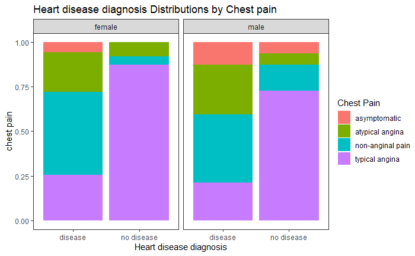

```r
# Create barplot by chest pain and gender
ggplot(heart.selected, aes(x = target, fill = cp)) +
  geom_bar(position = "fill") +
  facet_wrap(~sex) +
  labs(title = "Heart disease diagnosis Distributions by Chest pain",
       x = "Heart disease diagnosis",
       y = "chest pain") +
  scale_fill_discrete(name = "Chest Pain") +
  theme_test()
```

上图展示了四种cp在不同性别之下的情况，从结果来看，与总体是基本上是一致的。

由此我们可以认为，在进行分类的时候，无论性别，如果被观测者有着typical angina，那么他更容易被分到no disease。

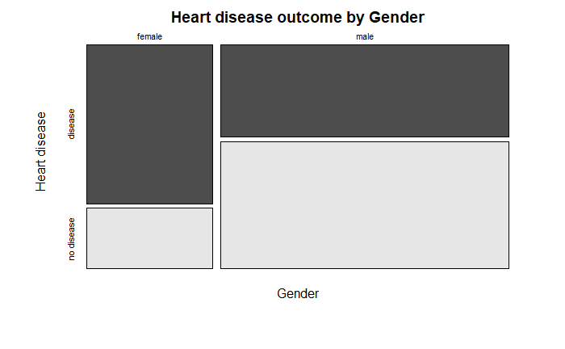

```r
mosaicplot(heart.selected$sex ~ heart.selected$target,
           main="Heart disease outcome by Gender", shade=FALSE,color=TRUE,
           xlab="Gender", ylab="Heart disease")
```

从上图来看，对于female而言，disease的占比较高，而male的disease则占比较低。

由此我们可以推论，如果被观测者是female，那么她被分类到disease的可能性就更高。

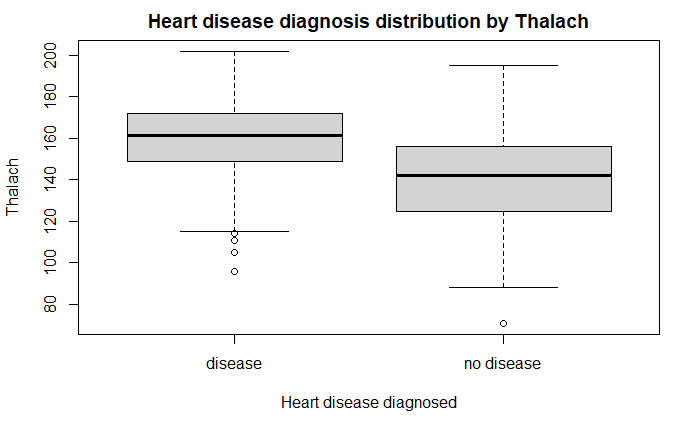

```r
boxplot(heart.selected$thalach ~ heart.selected$target,
        main="Heart disease diagnosis distribution by Thalach",
         ylab="Thalach",xlab="Heart disease diagnosed")
```

```r
NA
NA
```

从上图可以发现，disease的thalach总体上比no disease更高，这与常识相符合。

另外，thalach在disease上的outliers更多。由此可以认为，在一个人thalach的值相对较高的情况之下，这个人出现disease的可能性会更高，在分类的时候更容易被分类到disease类。

总体上来讲，没有哪一个变量能够做出非常准确的预测，所以在进行分类的时候，需要combine所有的变量。

## corr

```r
# calculate the correlation matrix
# if convert to factor


heart.selected$age <- as.numeric(heart.selected$age)
heart.selected$thalach <- as.numeric(heart.selected$thalach)
heart.selected$oldpeak <- as.numeric(heart.selected$oldpeak)
heart.selected$major_vessels <- as.numeric(heart.selected$major_vessels)


cor.matrix <- cor(heart.selected[, c("age",  "thalach", "oldpeak", "major_vessels")])
cor.matrix
```

```
                     age    thalach    oldpeak major_vessels
age            1.0000000 -0.3902271  0.2081367     0.2715505
thalach       -0.3902271  1.0000000 -0.3497962    -0.2078884
oldpeak        0.2081367 -0.3497962  1.0000000     0.2218160
major_vessels  0.2715505 -0.2078884  0.2218160     1.0000000
```

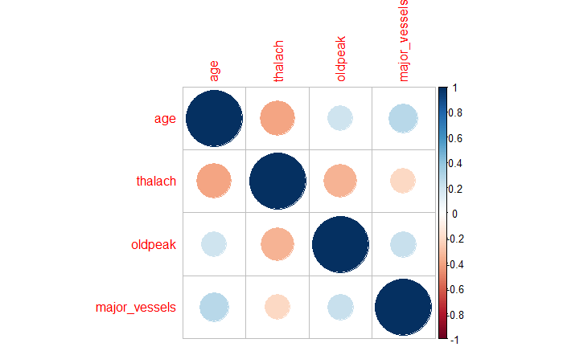

```r
corrplot(cor.matrix)
```

```r
NA
NA
```